# Protective antigen

Fold-switch pair **4h2aA_3j9cA** — **4h2aA** vs **3j9cA**

Bacillus anthracis

## Figure 1: Phylogenetic tree with per-cluster fold-preference heatmap.

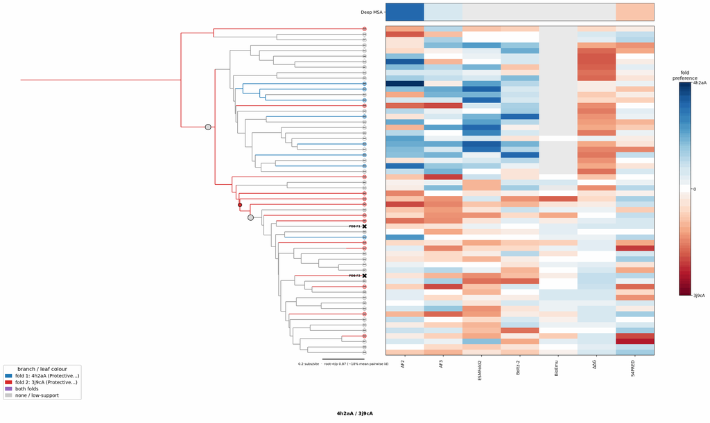

## Figure 2: Aligned overlay (both folds superposed)

The single fold-switching chain of each fold superposed by TM-align; waters hidden, any ligand shown as green sticks. Grey = structurally conserved core, colour = divergent (fold-switching) region.

4h2aA (Protective antigen)3j9cA (Protective antigen)

TM-score: 0.737 · Trigger class: equilibrium_or_unknown

Aligned overlay

Loading...

## Figure 3: The two folds, side by side

Each fold is coloured by per-residue Cα deviation between the two superposed structures: grey ≈ conserved core, full colour = structurally divergent (fold-switching) region.

4h2aA (Protective antigen)

3j9cA (Protective antigen)

0 Å5≥10 Å

4h2aA (Protective antigen)

Loading...

3j9cA (Protective antigen)

Loading...

## Figure 4: Best-cluster predicted contact maps over the two true folds.

Predicted contact maps (MSA-Transformer) for the clusters best matching each fold, over the true contacts of fold 1 (upper triangle) and fold 2 (lower). Divergent contacts between clusters are the contact-level signature of fold-switching.

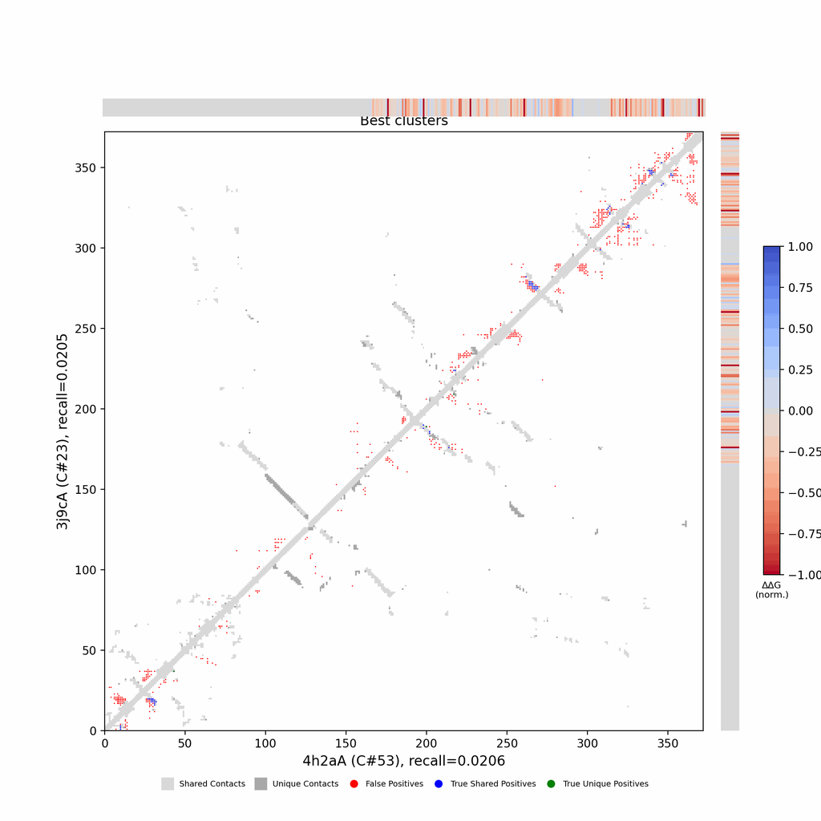

## Figure 5: Per-residue ΔΔG fold-preference contribution

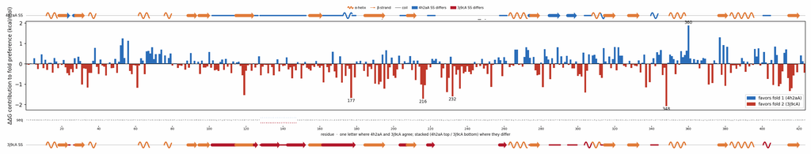

**More figures**

## Figure 6: Deep-MSA contact map panel / Best clusters contact map panel

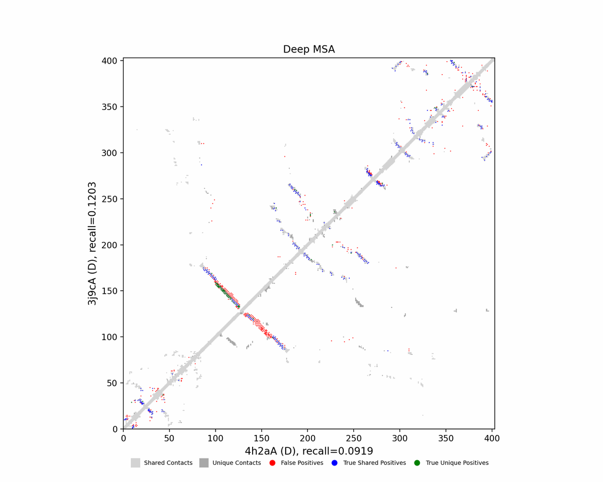

Deep-MSA contact map panel

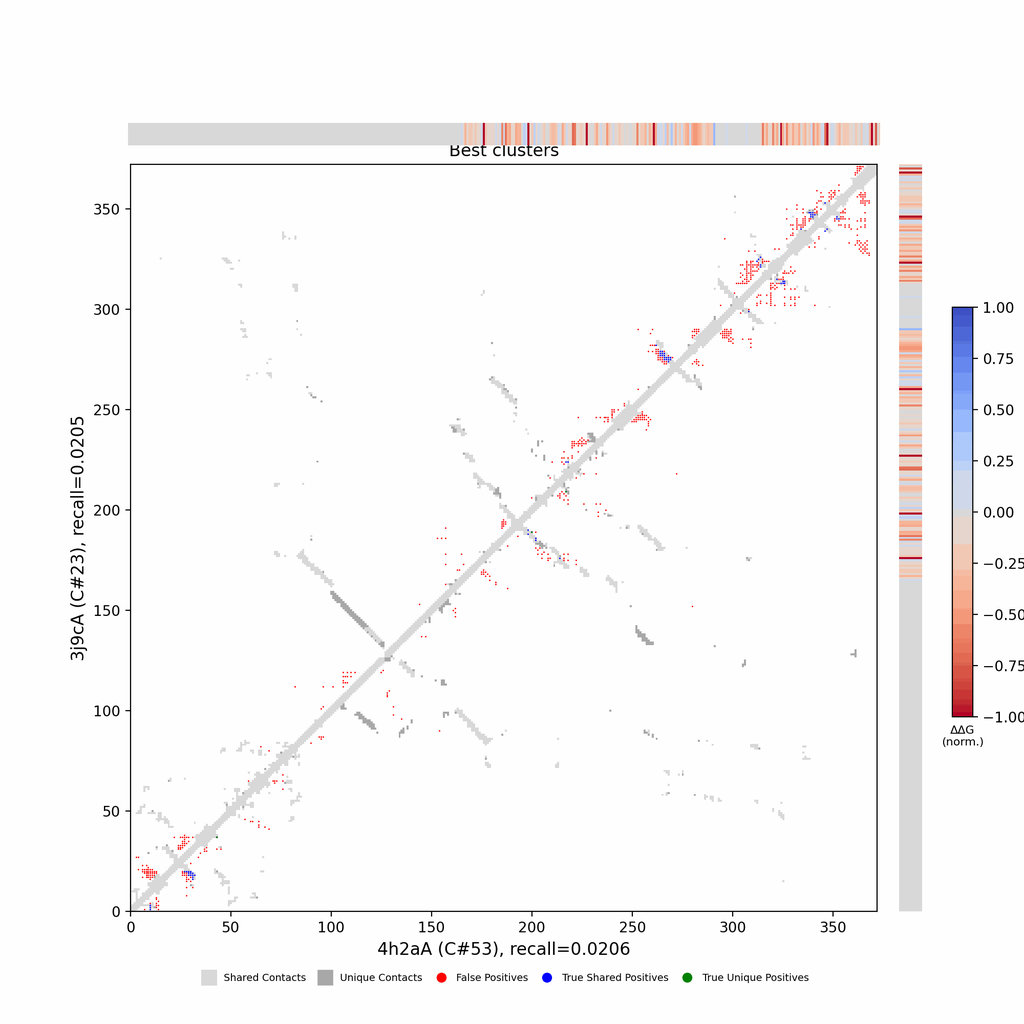

Best clusters contact map panel

## Figure 7: All clusters contact-map mosaic (small multiples).

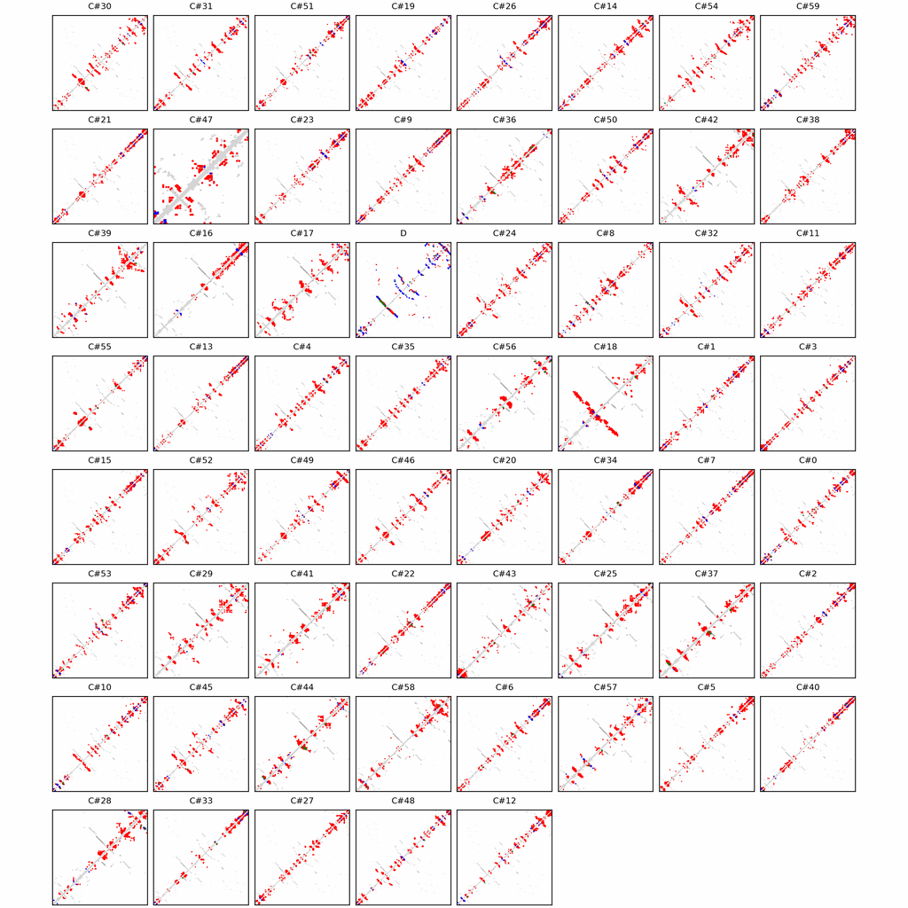

## Figure 8: Phylo null: tree with shuffled cluster fold labels.

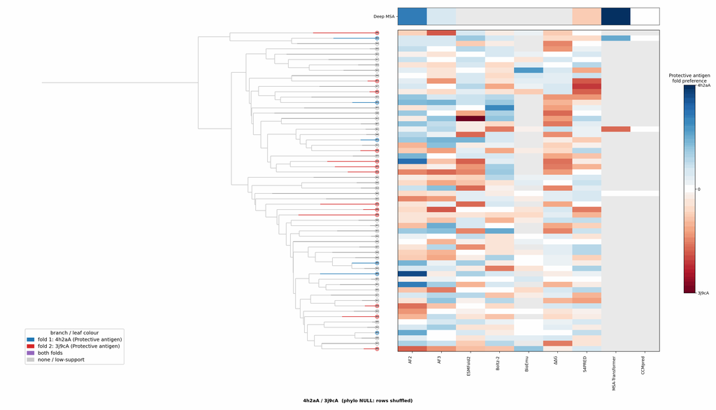

## Cluster metrics table

Per-cluster metrics underlying the figures above.

| cluster | n | neff | AF2_TM1 | AF2_TM2 | AF3_TM1 | AF3_TM2 | RE-MSAT-COM | RE-MSAT1 | RE-MSAT2 | ESM_SEQIDS | ESM_TM1 | ESM_TM2 | ΔΔG_Bias | ΔΔG_Bias_std | ΔΔG_frac_F1 | Boltz2_pref | S4PRED_pref | CCMpred_pref | BioEmu_pref |
| --- | --- | --- | --- | --- | --- | --- | --- | --- | --- | --- | --- | --- | --- | --- | --- | --- | --- | --- | --- |
| Deep | - | - | 0.86 | 0.76 | 0.81 | 0.78 | 0.32 | 0.28 | 0.38 | - | - | - | - | - | - | - | -0.02 | 0.0 | - |
| 000 | 22.0 | 8.0 | 0.2 | 0.29 | 0.2 | 0.3 | 0.03 | 0.02 | 0.03 | 002; 002; 001; 001; 005; 005; 006; 003; 003; 007 | 0.68 ± 0.04 | 0.67 ± 0.04 | -55.62 | 61.0 | 0.1 | -0.05 | 0.05 | 0.0 | -0.04 |
| 001 | 18.0 | 2.0 | 0.14 | 0.19 | 0.22 | 0.24 | 0.02 | 0.01 | 0.02 | 008; 008; 002; 002; 004; 004; 005; 009; 009; 005 | 0.66 ± 0.03 | 0.67 ± 0.01 | -40.04 | 30.62 | 0.0 | -0.1 | 0.05 | 0.0 | -0.05 |
| 002 | 16.0 | 6.0 | 0.23 | 0.27 | 0.3 | 0.35 | 0.02 | 0.02 | 0.01 | 002; 002; 006; 006; 001; 001; 003; 003; 007; 007 | 0.70 ± 0.03 | 0.68 ± 0.03 | -108.03 | 30.8 | 0.0 | -0.04 | 0.03 | 0.0 | - |
| 003 | 16.0 | 8.0 | 0.32 | 0.39 | 0.2 | 0.31 | 0.02 | 0.02 | 0.02 | - | - | - | -74.97 | 37.06 | 0.0 | -0.02 | 0.06 | - | -0.06 |
| 004 | - | - | 0.29 | 0.21 | 0.63 | 0.72 | 0.02 | 0.02 | 0.01 | - | - | - | -88.18 | 35.16 | 0.0 | -0.02 | 0.05 | - | - |
| 005 | 15.0 | 6.0 | 0.17 | 0.24 | 0.18 | 0.25 | 0.01 | 0.0 | 0.0 | - | - | - | -73.48 | 23.33 | 0.0 | -0.04 | 0.05 | - | -0.04 |
| 006 | 15.0 | 2.0 | 0.17 | 0.24 | 0.29 | 0.41 | 0.01 | 0.01 | 0.01 | - | - | - | -66.0 | 31.5 | 0.0 | -0.03 | 0.05 | - | -0.05 |
| 007 | 15.0 | 9.0 | 0.21 | 0.22 | 0.24 | 0.27 | 0.02 | 0.02 | 0.02 | - | - | - | -166.36 | 40.54 | 0.0 | -0.07 | 0.05 | - | - |
| 008 | 14.0 | 1.0 | 0.22 | 0.3 | 0.28 | 0.42 | 0.03 | 0.02 | 0.03 | - | - | - | -39.98 | 44.81 | 0.0 | -0.08 | 0.06 | - | -0.06 |
| 009 | 14.0 | 6.0 | 0.2 | 0.19 | 0.21 | 0.27 | 0.0 | 0.0 | 0.01 | - | - | - | -64.69 | 29.74 | 0.0 | -0.06 | 0.04 | - | -0.06 |
| 010 | 14.0 | 4.0 | 0.44 | 0.55 | 0.64 | 0.67 | 0.04 | 0.06 | 0.03 | - | - | - | -109.24 | 67.16 | 0.0 | -0.07 | 0.04 | - | - |
| 011 | 14.0 | 8.0 | 0.21 | 0.22 | 0.27 | 0.25 | 0.01 | 0.02 | 0.01 | - | - | - | -87.65 | 17.43 | 0.0 | -0.04 | 0.03 | - | - |
| 012 | 13.0 | 1.0 | 0.26 | 0.37 | 0.75 | 0.74 | 0.02 | 0.04 | 0.01 | - | - | - | -115.02 | 15.96 | 0.0 | -0.03 | 0.04 | - | - |
| 013 | 13.0 | 7.0 | 0.22 | 0.22 | 0.31 | 0.3 | 0.02 | 0.03 | 0.02 | - | - | - | -135.54 | 40.85 | 0.0 | -0.01 | 0.04 | - | - |
| 014 | 13.0 | 4.0 | 0.21 | 0.24 | 0.23 | 0.23 | 0.02 | 0.01 | 0.02 | - | - | - | -160.02 | 5.24 | 0.0 | -0.06 | 0.05 | - | - |
| 015 | 13.0 | 2.0 | 0.19 | 0.17 | 0.2 | 0.28 | 0.01 | 0.0 | 0.0 | - | - | - | -69.05 | 35.97 | 0.0 | -0.05 | 0.06 | - | -0.05 |
| 016 | 13.0 | 4.0 | 0.19 | 0.23 | 0.16 | 0.17 | 0.02 | 0.01 | 0.02 | - | - | - | -55.93 | 2.1 | 0.0 | -0.06 | 0.04 | - | -0.05 |
| 017 | 13.0 | 1.0 | 0.18 | 0.21 | 0.28 | 0.37 | 0.0 | 0.0 | 0.01 | - | - | - | -49.75 | 3.09 | 0.0 | -0.03 | 0.04 | - | -0.06 |
| 018 | 13.0 | 6.0 | 0.52 | 0.66 | 0.63 | 0.77 | 0.02 | 0.01 | 0.01 | - | - | - | -52.99 | 18.73 | 0.0 | -0.05 | 0.06 | - | - |
| 019 | 12.0 | 8.0 | 0.26 | 0.2 | 0.45 | 0.6 | 0.02 | 0.08 | 0.01 | - | - | - | -169.15 | 6.41 | 0.0 | -0.03 | 0.04 | - | - |
| 020 | 12.0 | 8.0 | 0.24 | 0.24 | 0.3 | 0.39 | 0.02 | 0.02 | 0.02 | - | - | - | -140.66 | 14.62 | 0.0 | -0.02 | 0.02 | - | - |
| 021 | 12.0 | 6.0 | 0.2 | 0.3 | 0.25 | 0.23 | 0.01 | 0.01 | 0.01 | - | - | - | -138.49 | 9.94 | 0.0 | -0.05 | 0.03 | - | - |
| 022 | 12.0 | 2.0 | 0.21 | 0.21 | 0.23 | 0.28 | 0.02 | 0.01 | 0.01 | - | - | - | -151.28 | 8.53 | 0.0 | -0.02 | 0.02 | - | - |
| 023 | 12.0 | 4.0 | 0.2 | 0.28 | 0.26 | 0.26 | 0.04 | 0.03 | 0.03 | - | - | - | -148.09 | 9.81 | 0.0 | -0.02 | 0.06 | - | - |
| 024 | 12.0 | 4.0 | 0.27 | 0.34 | 0.31 | 0.43 | 0.01 | 0.01 | 0.01 | - | - | - | -70.02 | 31.68 | 0.0 | -0.06 | 0.06 | - | -0.05 |
| 025 | 12.0 | 6.0 | 0.28 | 0.33 | 0.38 | 0.49 | 0.0 | 0.02 | 0.0 | - | - | - | -55.31 | 4.39 | 0.0 | -0.05 | 0.02 | - | -0.04 |
| 026 | 12.0 | 6.0 | 0.14 | 0.18 | 0.23 | 0.28 | 0.02 | 0.01 | 0.01 | - | - | - | -74.17 | 39.47 | 0.0 | -0.1 | 0.06 | - | -0.06 |
| 027 | 12.0 | 3.0 | 0.19 | 0.23 | 0.22 | 0.3 | 0.01 | 0.0 | 0.0 | - | - | - | -51.79 | 29.22 | 0.0 | -0.08 | -0.0 | - | -0.04 |
| 028 | 12.0 | 1.0 | 0.2 | 0.29 | 0.24 | 0.38 | 0.0 | 0.0 | 0.0 | - | - | - | -57.43 | 2.23 | 0.0 | -0.07 | 0.06 | - | -0.06 |
| 029 | 12.0 | 1.0 | 0.32 | 0.41 | 0.4 | 0.51 | 0.01 | 0.02 | 0.01 | - | - | - | -60.25 | 10.95 | 0.0 | -0.07 | 0.02 | - | -0.08 |
| 030 | 12.0 | 5.0 | 0.25 | 0.33 | 0.29 | 0.46 | 0.01 | 0.01 | 0.01 | - | - | - | -76.31 | 26.31 | 0.0 | -0.07 | 0.06 | - | -0.09 |
| 031 | 12.0 | 6.0 | 0.28 | 0.36 | 0.66 | 0.66 | 0.01 | 0.09 | 0.01 | - | - | - | -137.08 | 41.64 | 0.0 | -0.02 | 0.02 | - | - |
| 032 | 12.0 | 8.0 | 0.26 | 0.35 | 0.5 | 0.58 | 0.02 | 0.05 | 0.01 | - | - | - | -164.16 | 7.61 | 0.0 | -0.0 | 0.02 | - | - |
| 033 | 11.0 | 6.0 | 0.18 | 0.19 | 0.21 | 0.25 | 0.04 | 0.02 | 0.04 | - | - | - | -164.6 | 10.8 | 0.0 | -0.01 | 0.04 | - | - |
| 034 | 11.0 | 3.0 | 0.18 | 0.22 | 0.24 | 0.28 | 0.04 | 0.02 | 0.04 | - | - | - | -160.39 | 35.91 | 0.0 | -0.06 | 0.04 | - | - |
| 035 | 11.0 | 2.0 | 0.3 | 0.38 | 0.25 | 0.32 | 0.02 | 0.01 | 0.01 | - | - | - | -144.02 | 13.2 | 0.0 | -0.02 | 0.04 | - | - |
| 036 | 11.0 | 4.0 | 0.19 | 0.25 | 0.23 | 0.38 | 0.01 | 0.01 | 0.01 | - | - | - | -70.16 | 25.21 | 0.0 | -0.05 | 0.04 | - | -0.04 |
| 037 | 11.0 | 3.0 | 0.18 | 0.21 | 0.21 | 0.23 | 0.0 | 0.01 | 0.0 | - | - | - | -56.56 | 4.45 | 0.0 | -0.08 | 0.02 | - | -0.05 |
| 038 | 11.0 | 2.0 | 0.14 | 0.18 | 0.2 | 0.28 | 0.0 | 0.0 | 0.0 | - | - | - | -48.4 | 20.33 | 0.0 | -0.05 | 0.04 | - | -0.04 |
| 039 | 11.0 | 4.0 | 0.22 | 0.31 | 0.5 | 0.71 | 0.01 | 0.0 | 0.01 | - | - | - | -43.01 | 4.08 | 0.0 | -0.04 | 0.01 | - | -0.05 |
| 040 | 11.0 | 6.0 | 0.18 | 0.24 | 0.2 | 0.25 | 0.03 | 0.02 | 0.03 | - | - | - | -66.65 | 37.4 | 0.0 | -0.03 | 0.06 | - | -0.05 |
| 041 | 11.0 | 1.0 | 0.2 | 0.27 | 0.22 | 0.34 | 0.0 | 0.02 | 0.0 | - | - | - | -47.51 | 3.47 | 0.0 | -0.06 | 0.01 | - | -0.08 |
| 042 | 11.0 | 2.0 | 0.25 | 0.36 | 0.4 | 0.58 | 0.0 | 0.01 | 0.0 | - | - | - | -53.2 | 6.57 | 0.0 | -0.05 | 0.06 | - | -0.07 |
| 043 | 11.0 | 7.0 | 0.27 | 0.41 | 0.49 | 0.66 | 0.01 | 0.01 | 0.01 | - | - | - | -57.67 | 15.58 | 0.0 | -0.04 | 0.05 | - | -0.06 |
| 044 | 11.0 | 6.0 | 0.2 | 0.29 | 0.23 | 0.38 | 0.0 | 0.02 | 0.0 | - | - | - | -64.4 | 6.04 | 0.0 | -0.03 | 0.03 | - | -0.05 |
| 045 | 11.0 | 3.0 | 0.46 | 0.6 | 0.42 | 0.6 | 0.03 | 0.02 | 0.02 | - | - | - | -88.53 | 31.04 | 0.0 | -0.08 | 0.06 | - | -0.07 |
| 046 | 11.0 | 7.0 | 0.26 | 0.36 | 0.4 | 0.6 | 0.01 | 0.01 | 0.0 | - | - | - | -119.35 | 46.34 | 0.0 | -0.06 | 0.05 | - | -0.06 |
| 047 | 11.0 | 4.0 | 0.28 | 0.35 | 0.74 | 0.76 | 0.03 | 0.01 | 0.03 | - | - | - | -59.85 | 32.91 | 0.0 | -0.05 | 0.06 | - | - |
| 048 | 10.0 | 9.0 | 0.26 | 0.27 | 0.55 | 0.63 | 0.01 | 0.08 | 0.01 | - | - | - | -172.5 | 9.66 | 0.0 | -0.03 | 0.04 | - | - |
| 049 | 10.0 | 9.0 | 0.23 | 0.26 | 0.24 | 0.32 | 0.02 | 0.04 | 0.01 | - | - | - | -156.19 | 7.34 | 0.0 | -0.02 | 0.05 | - | - |
| 050 | 10.0 | 4.0 | 0.19 | 0.22 | 0.27 | 0.35 | 0.02 | 0.07 | 0.01 | - | - | - | -155.0 | 5.81 | 0.0 | -0.03 | 0.05 | - | - |
| 051 | 10.0 | 7.0 | 0.23 | 0.19 | 0.27 | 0.28 | 0.01 | 0.01 | 0.01 | - | - | - | -137.29 | 4.84 | 0.0 | -0.04 | 0.04 | - | - |
| 052 | 10.0 | 3.0 | 0.33 | 0.34 | 0.36 | 0.36 | 0.0 | 0.0 | 0.02 | - | - | - | -157.47 | 8.16 | 0.0 | 0.02 | 0.06 | - | - |
| 053 | 10.0 | 7.0 | 0.24 | 0.31 | 0.64 | 0.68 | 0.04 | 0.06 | 0.03 | - | - | - | -146.19 | 12.95 | 0.0 | 0.02 | 0.05 | - | - |
| 054 | 10.0 | 6.0 | 0.42 | 0.56 | 0.5 | 0.7 | 0.01 | 0.02 | 0.01 | - | - | - | -147.07 | 16.22 | 0.0 | -0.02 | 0.04 | - | - |
| 055 | 10.0 | 6.0 | 0.3 | 0.42 | 0.26 | 0.34 | 0.0 | 0.01 | 0.0 | - | - | - | -99.84 | 36.38 | 0.0 | -0.05 | 0.04 | - | -0.06 |
| 056 | 10.0 | 2.0 | 0.15 | 0.2 | 0.23 | 0.31 | 0.0 | 0.01 | 0.0 | - | - | - | -59.37 | 2.94 | 0.0 | -0.06 | 0.04 | - | -0.05 |
| 057 | 10.0 | 7.0 | 0.15 | 0.19 | 0.39 | 0.56 | 0.02 | 0.01 | 0.01 | - | - | - | -60.11 | 5.4 | 0.0 | -0.06 | 0.0 | - | -0.05 |
| 058 | 10.0 | 5.0 | 0.26 | 0.32 | 0.21 | 0.32 | 0.01 | 0.01 | 0.01 | - | - | - | -57.85 | 9.04 | 0.0 | -0.06 | 0.06 | - | -0.06 |
| 059 | 10.0 | 3.0 | 0.42 | 0.51 | 0.46 | 0.63 | 0.04 | 0.14 | 0.03 | - | - | - | -106.31 | 44.07 | 0.0 | -0.09 | 0.06 | - | -0.12 |